# petards

JcB

04/12/2014

## Question de l’ARS (AC Schieber)

Nous avons reçu une demande, cf ci-dessous, de la part de la préfecture du Haut-Rhin : pourriez-vous nous indiquer à partir de la base des RPU le nombre de passage dans la nuit du **31 décembre au 1er janvier 2014 (20h-8h)**, en donnant le total pour le 68? (mais du coup, il n’y aura pas Thann, ni la clinique du Diaconat Roosevelt).

Cependant, cette requête n’a du sens à mon avis, que si on confronte ce chiffre à la moyenne annuelle sur la même tranche horaire = moyenne du nombre de passage dans le 68 de 20h à 8h, qu’en pensez-vous?

## Réponse

[Voir vigette lubridate](http://cran.r-project.org/web/packages/lubridate/vignettes/lubridate.html)

Les calculs se font à partir de la colonne ENTREE qui contient des objets DateTime au format Character. Il faut donc transformer des chaines de caractères en objets temporels. C’est le travail de la fonction **parse_date_time**:

```
POSIXct <- parse_date_time(character, format)
```

```
date1 <- as.POSIXct("2013-12-31 19:59:59")
date2 <- as.POSIXct("2014-01-01 07:59:59")

i <- new_interval(date1, date2)
as.duration(i)
as.numeric(as.duration(i))/3600
```

Lorsque un objet datetime est au format POSIXct, on peut extraire le groupe horaire avec **format**:

```
format(date1, "%X")
```

et la date au format local:

```
format(date1, "%x")
```

```r
library("lubridate")
source("../../Preparation/RPU Quotidiens/quot_utils.R")

# on récupère le fichier 2013-2014 sous le nom de d2
load("~/Documents/Resural/Stat Resural/RPU_2014/rpu2013-2014.Rda")

# RPU du Haut-Rhin en 2013 et 2014
d68 <- d2[d2$FINESS %in% c("Col","Geb","Mul","Alk","3Fr","Dia"), ]

# on forme un dataframe réduit ne comprtant que le 31 décembre et le 1er janvier
petards <- d2[d2$FINESS %in% c("Col","Geb","Mul","Alk","3Fr","Dia") & as.Date(d2$ENTREE) > "2013-12-30" &  as.Date(d2$ENTREE) < "2014-01-02", c("ENTREE", "DP", "FINESS")]

# nombre de passages dans les hôpitaux pendant ces deux jours
table(factor(petards$FINESS))
```

```
##
## 3Fr Alk Col Dia Geb Mul
##  97  25 329 146  82 283
```

```r
# création d'une colonne avec uniquement les heures
petards$heure <- substr(petards$ENTREE, 12, length(petards$ENTREE))

# on forme une colonne date time qui transforme la colonne ENTREE de type caractère en objet temporel via la méthode parse_date_time. On aurait probablement pu aussi utiliser la méthode ymd_hms. Les objets de la colonne datetime sont de type POSIXt.
petards$datetime <- parse_date_time(petards$ENTREE, "%Y-%m-%d %H:%M:%S")

# on définit l'intervalle i qui nous intéresse: le 31 à partir de 20h jusqu'au 1er 8 heures:
date1 <- as.POSIXct("2013-12-31 19:59:59")
date2 <- as.POSIXct("2014-01-01 07:59:59")
i <- new_interval(date1, date2)
i
```

```
## [1] 2013-12-31 19:59:59 CET--2014-01-01 07:59:59 CET
```

```r
# uniquement la nuit du réveillon: toutes les dates/heures qui tombent dans l'intervalle i.
p.reveillon <- petards[ymd_hms(petards$datetime) %within% i, ]
t <- table(factor(p.reveillon$FINESS))
t
```

```
##
## 3Fr Alk Col Dia Geb Mul
##  21   3  55  27   8  88
```

```r
sum(t)
```

```
## [1] 202
```

```
S60-S69  Lésions traumatiques du poignet et de la main

S60  Lésion traumatique superficielle du poignet et de la main
S61 Plaie ouverte du poignet et de la main
S62 Fracture au niveau du poignet et de la main
S63 Luxation, entorse et foulure d'articulations et de ligaments au niveau du poignet et de la main
S64 Lésion traumatique de nerfs au niveau du poignet et de la main
S65 Lésion traumatique de vaisseaux sanguins au niveau du poignet et de la main
S66 Lésion traumatique de muscles et de tendons au niveau du poignet et de la main
S67 Ecrasement du poignet et de la main
S68 Amputation traumatique du poignet et de la main
S69 Lésions traumatiques du poignet et de la main, autres et sans précision

S0230  TRAUMA   Traumatologique TRAU_TETEC  Traumatologie de la tête et du cou  TRAU_OPHT   Lésions de l'oeil ou de l'orbite
S0231   TRAUMA  Traumatologique TRAU_TETEC  Traumatologie de la tête et du cou  TRAU_OPHT   Lésions de l'oeil ou de l'orbite
S050  TRAUMA    Traumatologique TRAU_TETEC  Traumatologie de la tête et du cou  TRAU_OPHT   Lésions de l'oeil ou de l'orbite
S051    TRAUMA  Traumatologique TRAU_TETEC  Traumatologie de la tête et du cou  TRAU_OPHT   Lésions de l'oeil ou de l'orbite
S054    TRAUMA  Traumatologique TRAU_TETEC  Traumatologie de la tête et du cou  TRAU_OPHT   Lésions de l'oeil ou de l'orbite
S055    TRAUMA  Traumatologique TRAU_TETEC  Traumatologie de la tête et du cou  TRAU_OPHT   Lésions de l'oeil ou de l'orbite
S056    TRAUMA  Traumatologique TRAU_TETEC  Traumatologie de la tête et du cou  TRAU_OPHT   Lésions de l'oeil ou de l'orbite

W39 Projections de feu d'artifice

Y25  Contact avec matériel explosif, intention non déterminée
Y25.9   Contact avec du matériel explosif
```

# Question 2

Quel est le nombre moyen de RPU entre 20h et 8h dans le 68 en 2013

## réponse

La difficulté vient du fait que cet horaire est à cheval sur 2 jours. Idée: faire 2 listes: - soir <- tous les RPU de 20h à 0h - nuit <- tous les RPU de 0H à 8h à partir du fichier du haut-rhin = d68

Récupération de l’heure à partir de la colonne ENTREE

```
h <- substr(a,12,20) # récupère l'heure
```

```r
# calendrier 2013. On a besoin d'un calendrier de référence pour l'abnnée 2013
year2013 <- seq(as.Date("2013-01-01"), as.Date("2013-12-31"), 1)

# RPU 2013 dans le 68 (tous les RPU)
d68_2013 <- d68[as.Date(d68$ENTREE) < "2014-01-01",]

# soir = nombre de <RPU entre 20h et minuit
# nuit = nobre de RPU entre minuit et 8 heures
soir <- d68_2013[hms(substr(d68_2013$ENTREE,12,20)) > hms("19:59:59") & hms(substr(d68_2013$ENTREE,12,20)) <= hms("23:59:59"), ]
nuit <- d68_2013[hms(substr(d68_2013$ENTREE,12,20)) >= hms("00:00:00") & hms(substr(d68_2013$ENTREE,12,20)) < hms("08:00:00"), ]

n.soir <- nrow(soir)
n.nuit <- nrow(nuit)

n.soir/365 # moyenne empirique
```

```
## [1] 85.60548
```

```r
# nombre de RPU par jour durant la période SOIR
a <- tapply(as.Date(soir$ENTREE), yday(soir$ENTREE), length)
mean(a)
```

```
## [1] 85.84066
```

```r
sd(a)
```

```
## [1] 17.25252
```

```r
# idem pourla NUIT
b <- tapply(as.Date(nuit$ENTREE), yday(nuit$ENTREE), length)
mean(b)
```

```
## [1] 57.83791
```

```r
sd(b)
```

```
## [1] 14.14422
```

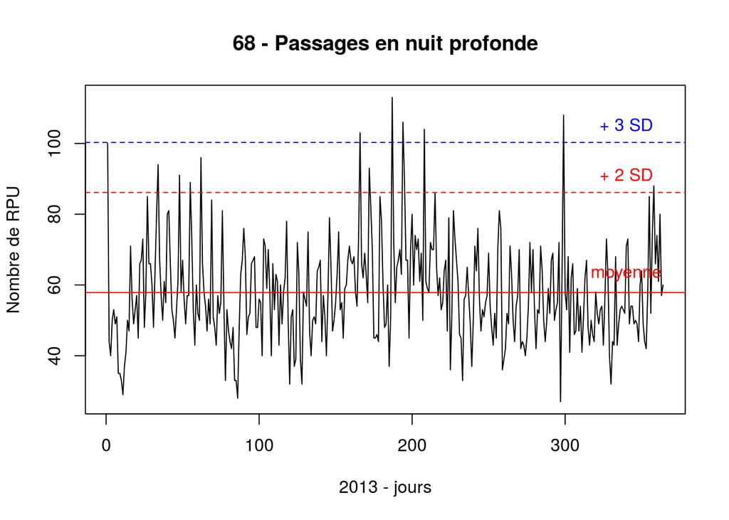

```r
# nuit profonde
plot(b, type = "l", main="68 - Passages en nuit profonde", xlab = "2013 - jours", ylab = "Nombre de RPU")
mb <- mean(b)
sdb <- sd(b)

abline(h = mb, col = "red")
sd2 <- mb + 2 * sdb
sd3 <- mb + 3 * sdb

abline(h = mean(b) + 2 * sdb, col = "red", lty = 2)
abline(h = mean(b) + 3 * sd(b), col = "blue", lty = 2)
text( 340, mean(b) + 5, "moyenne", col="red")
text( 340, mean(b) + 2 * sd(b) + 5, "+ 2 SD", col="red")
text( 340, mean(b) + 3 * sd(b) + 5, "+ 3 SD", col="blue")
```

```r
# jour pù le nombre de passage est supérieur à 3 ET
for(i in 1:length(year2013)){ j = yday(year2013[i]); if(!is.na(b[j]) & b[j] > sd3) print(paste(year2013[i], wday(year2013[i], label = TRUE), sep=" "))}
```

```
## [1] "2013-06-15 Sat"
## [1] "2013-07-06 Sat"
## [1] "2013-07-13 Sat"
## [1] "2013-07-27 Sat"
## [1] "2013-10-26 Sat"
```

```r
# jour pù le nombre de passage est supérieur à 2 ET
for(i in 1:length(year2013)){ j = yday(year2013[i]); if(!is.na(b[j]) & b[j] > sd2) print(paste(year2013[i], wday(year2013[i], label = TRUE), sep=" "))}
```

```
## [1] "2013-01-01 Tues"
## [1] "2013-02-03 Sun"
## [1] "2013-02-17 Sun"
## [1] "2013-02-24 Sun"
## [1] "2013-03-03 Sun"
## [1] "2013-06-15 Sat"
## [1] "2013-06-21 Fri"
## [1] "2013-07-06 Sat"
## [1] "2013-07-13 Sat"
## [1] "2013-07-14 Sun"
## [1] "2013-07-27 Sat"
## [1] "2013-10-26 Sat"
## [1] "2013-12-24 Tues"
```

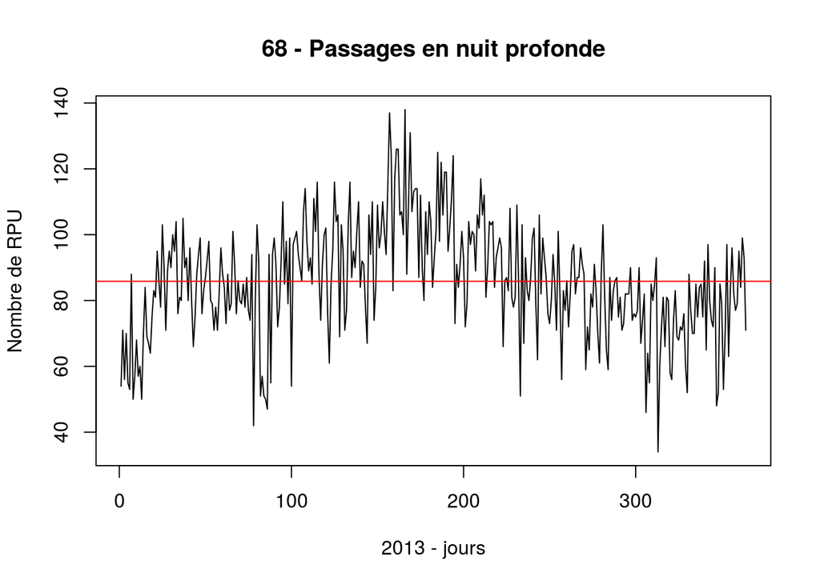

```r
# soirée
plot(a, type = "l", main="68 - Passages en nuit profonde", xlab = "2013 - jours", ylab = "Nombre de RPU")
abline(h = mean(a), col = "red")
```

## Nombre moyen de RPU de 20h à 8h

On a 2 vecteurs:

- a <- pour le soir
- b <- pour la nuit

Le nombre de RPU pour une tranche horaire de 20h à 8h est égal à la somme des RPU de la soirée J et de la nuit J + 1. Il faut donc supprimer la 1ère nuit de sorte que la soirée 1 corresponde à la nuit 2.

Le 31 décembre, il va manquer la nuit du 1er janvier. Il faut doc supprimer la soirée du 31/12.

```r
jour.manquant <- yday("2013-05-31")
a <- tapply(as.Date(soir$ENTREE), yday(soir$ENTREE), length)
b <- tapply(as.Date(nuit$ENTREE), yday(nuit$ENTREE), length)

a2 <- c(a[1:150], NA, a[151:364]) # on intercale NA en position 151.
a2 <- a2[-365]

b2 <- c(b[1:150], NA, b[151:364])
b2 <- b2[-1]

c <- a2 + b2

m <- mean(c, na.rm=T)
s <- sd(c, na.rm=T)

m
```

```
## [1] 143.5249
```

```r
s
```

```
## [1] 25.01403
```

```r
m + s
```

```
## [1] 168.5389
```

```r
m - s
```

```
## [1] 118.5108
```

```r
m + 2 * s
```

```
## [1] 193.5529
```

```r
m - 2 * s
```

```
## [1] 93.49681
```

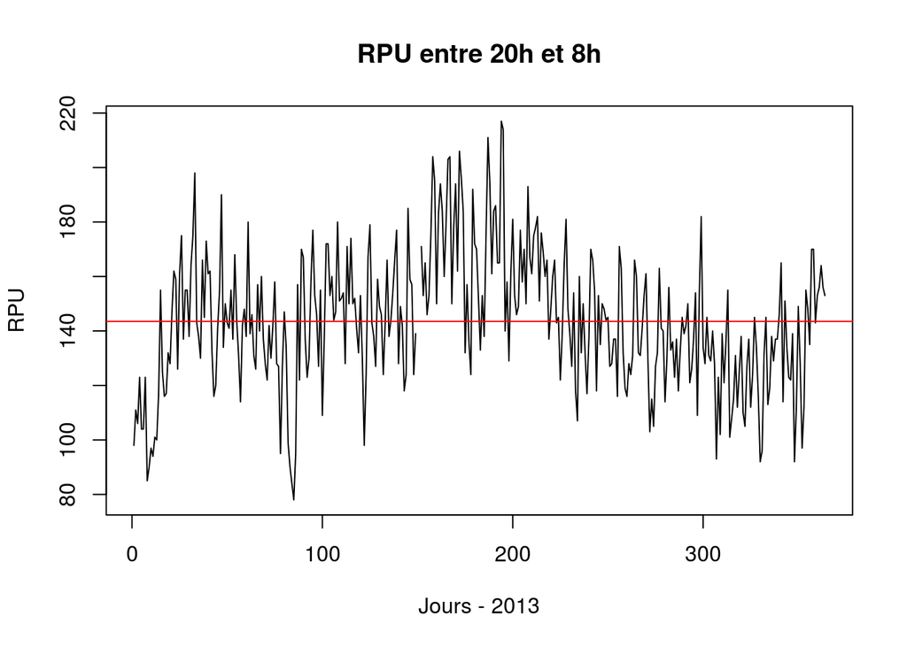

```r
plot(c, type = "l", main="RPU entre 20h et 8h", xlab = "Jours - 2013", ylab = "RPU")
abline( h=mean(c, na.rm=T), col="red")
```

### Nombre moyen de RPU dans le 68:

En 2013, on compte en moyenne 143.52 RPU entre 20 heures et 8 heures (écart-type = 25.01 RPU.)

## Trouver une date manquante

En 2013, il manque la journée du 31 mai 2013. Pour retrouver cette date, on compare la liste des dates 2013 (a) à un calendrier de référence (year2013)

```r
getwd()
```

```
## [1] "/home/jcb/Documents/Resural/Stat Resural/RPU_2014/Analyse/Petards"
```

```r
source("../../Preparation/RPU Quotidiens/quot_utils.R")
jours.manquants("2013-01-01", "2013-12-31", d68_2013$ENTREE)
```

```
## [1] "2013-05-31"
```

## Lésions spécifiques de la main 68

```r
dp <- substr(petards$DP, 1, 3)
main68 <- dp[!is.na(dp) & dp %in% c("S60", "S61", "S62", "S63", "S64", "S65", "S66", "S67", "S68", "S69")]
table(main68)
```

```
## main68
## S60 S61 S62 S63
##  14  15   7   4
```

# Analyse des pétards dans le 67

```r
# RPU du Bas-Rhin en 2013 et 2014
d67 <- d2[d2$FINESS %in% c("Wis", "Sav", "Hag", "Hus", "Odi", "Ane", "Dts", "Sel"), ]
# uniquement en 2013
d67_2013 <- d2[d2$FINESS %in% c("Wis", "Sav", "Hag", "Hus", "Odi", "Ane", "Dts", "Sel") & as.Date(d2$ENTREE) < "2014-01-01", ]

# on forme un dataframe réduit ne comprtant que le 31 décembre et le 1er janvier
petards67 <- d2[d2$FINESS %in% c("Wis", "Sav", "Hag", "Hus", "Odi", "Ane", "Dts", "Sel") & as.Date(d2$ENTREE) > "2013-12-30" &  as.Date(d2$ENTREE) < "2014-01-02", c("ENTREE", "DP", "FINESS")]

# nombre de passages dans les hôpitaux pendant ces deux jours
table(factor(petards67$FINESS))
```

```
##
## Hag Hus Odi Sel Wis Sav
## 193 184 125 184  78 164
```

```r
# on forme une colonne date time qui transforme la colonne ENTREE de type caractère en objet temporel via la méthode parse_date_time. On aurait probablement pu aussi utiliser la méthode ymd_hms. Les objets de la colonne datetime sont de type POSIXt.
petards67$datetime <- parse_date_time(petards67$ENTREE, "%Y-%m-%d %H:%M:%S")

# on définit l'intervalle i qui nous intéresse: le 31 à partir de 20h jusqu'au 1er 8 heures:
date1 <- as.POSIXct("2013-12-31 19:59:59")
date2 <- as.POSIXct("2014-01-01 07:59:59")
i <- new_interval(date1, date2)
i
```

```
## [1] 2013-12-31 19:59:59 CET--2014-01-01 07:59:59 CET
```

```r
# uniquement la nuit du réveillon: toutes les dates/heures qui tombent dans l'intervalle i.
p.reveillon <- petards67[ymd_hms(petards67$datetime) %within% i, ]
t <- table(factor(p.reveillon$FINESS))
t
```

```
##
## Hag Hus Odi Sel Wis Sav
##  41  38  12  46  15  28
```

```r
sum(t)
```

```
## [1] 180
```

```r
# soir = nombre de <RPU entre 20h et minuit
# nuit = nobre de RPU entre minuit et 8 heures
soir67 <- d67_2013[hms(substr(d67_2013$ENTREE,12,20)) > hms("19:59:59") & hms(substr(d67_2013$ENTREE,12,20)) <= hms("23:59:59"), ]
nuit67 <- d67_2013[hms(substr(d67_2013$ENTREE,12,20)) >= hms("00:00:00") & hms(substr(d67_2013$ENTREE,12,20)) < hms("08:00:00"), ]

n.soir <- nrow(soir67)
n.nuit <- nrow(nuit67)

n.soir/365 # moyenne empirique
```

```
## [1] 78.55068
```

```r
n.nuit/365
```

```
## [1] 45.87671
```

```r
(n.soir + n.nuit)/365 # moyenne nuit + soirée
```

```
## [1] 124.4274
```

```r
# nombre de RPU par jour durant la période SOIR
a <- tapply(as.Date(soir67$ENTREE), yday(soir67$ENTREE), length)
mean(a)
```

```
## [1] 78.76648
```

```r
sd(a)
```

```
## [1] 12.92201
```

```r
# idem pourla NUIT
b <- tapply(as.Date(nuit67$ENTREE), yday(nuit67$ENTREE), length)
mean(b)
```

```
## [1] 46.00275
```

```r
sd(b)
```

```
## [1] 11.3968
```

```r
#total nuit + soir = garde
total_garde67 <- rbind(soir67, nuit67)
tot  <- tapply(as.Date(total_garde67$ENTREE), yday(total_garde67$ENTREE), length)
mean(tot)
```

```
## [1] 124.7692
```

```r
sd(tot)
```

```
## [1] 17.97263
```

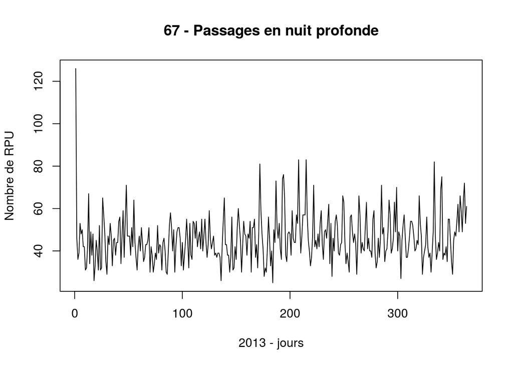

```r
# nuit profonde
plot(b, type = "l", main="67 - Passages en nuit profonde", xlab = "2013 - jours", ylab = "Nombre de RPU")
```

```r
mb <- mean(b)
sdb <- sd(b)
```

## Méthode 2

On forme 2 vecteurs de 365 jours, l’un pour compter le nombre de RPU quotidiens engegistrés le soir (a) et l’autre pour les RPU de la nuit (b). La garde est formée de la soirée du jour j et de la nuit du jour j+1. Pour calculer le nomre de RPU correspondants à une garde il faut retirer de (b) la nuit du jour 1 (0h-8h) qui n’a pas de soirée correspondante et la soirée du réveillon (a) qui n’a pas de nuit correspondante.

e plus il faut intercaler le jour 151 (31 mai) qui est manquant. On le remplace par NA.

```r
jour.manquant <- yday("2013-05-31")
a <- tapply(as.Date(soir67$ENTREE), yday(soir67$ENTREE), length)
b <- tapply(as.Date(nuit67$ENTREE), yday(nuit67$ENTREE), length)

a2 <- c(a[1:150], NA, a[151:364]) # on intercale NA en position 151.
a2 <- a2[-365]

b2 <- c(b[1:150], NA, b[151:364])
b2 <- b2[-1]

c <- a2 + b2 # c = total des RPU pour une garde

m <- mean(c, na.rm=T)
s <- sd(c, na.rm=T)

m
```

```
## [1] 124.5552
```

```r
s
```

```
## [1] 18.91425
```

```r
m + s
```

```
## [1] 143.4695
```

```r
m - s
```

```
## [1] 105.641
```

```r
m + 2 * s
```

```
## [1] 162.3838
```

```r
m - 2 * s
```

```
## [1] 86.72674
```

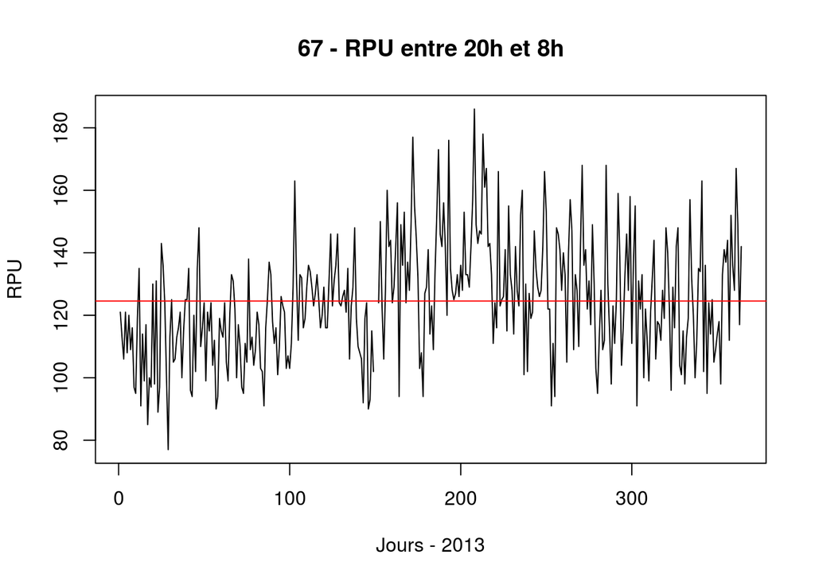

```r
plot(c, type = "l", main="67 - RPU entre 20h et 8h", xlab = "Jours - 2013", ylab = "RPU")
abline( h=mean(c, na.rm=T), col="red")
```

### Nombre moyen de RPU pour le 67 en garde:

En 2013, on compte en moyenne 124.56 RPU entre 20 heures et 8 heures (écart-type = 18.91 RPU.)

## Lésions spécifiques de la main 67

```r
dp <- substr(petards67$DP, 1, 3)
main67 <- dp[!is.na(dp) & dp %in% c("S60", "S61", "S62", "S63", "S64", "S65", "S66", "S67", "S68", "S69")]
table(main67)
```

```
## main67
## S60 S61 S62 S63
##   8  20   6   9
```

# Analyse sur 1 mois

Analyse de la traumato de la main du 15 décembre au 15 janvier

- periode.pet: tous les RPU de la période
- pet.dp: uniquement la trauma de la main sur 2 varaibles: entrées et dp
- pet.dp.plaie: idem mais limité aux plaies de la main (S60 et S61)

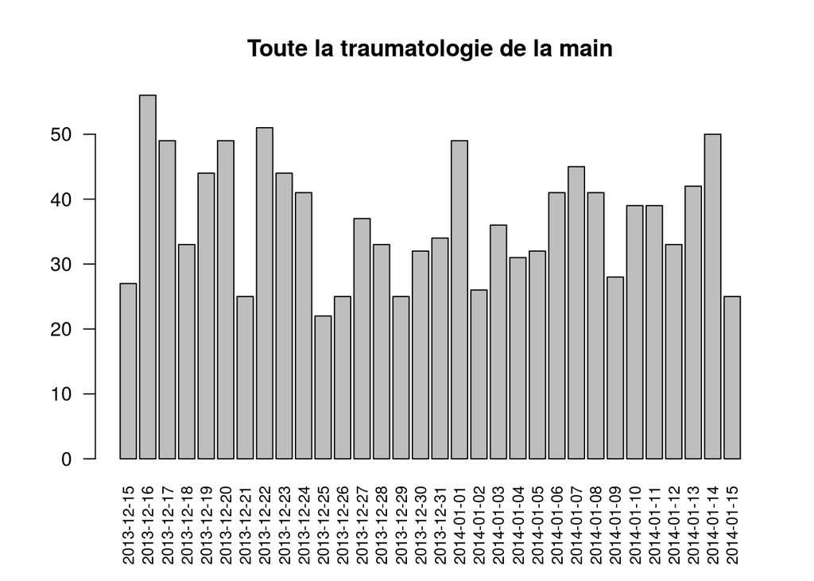

```r
# on étudie la période du 15 décembre au 15 janvier
periode.pet <- d2[as.Date(d2$ENTREE) > "2013-12-14" & as.Date(d2$ENTREE) < "2014-01-16", ]

# corrige les caractères anormaux
periode.pet$MOTIF <- normalise.caracteres(periode.pet$MOTIF)
periode.pet$DP <- normalise.caracteres(periode.pet$DP)
pet <- periode.pet[, c("ENTREE", "DP", "MOTIF")]
pet.dp <- pet[!is.na(pet$DP) & substr(pet$DP, 1, 3) %in% c("S60", "S61", "S62", "S63", "S64", "S65", "S66", "S67", "S68", "S69"), c("ENTREE","DP")]
t <- tapply(as.Date(pet.dp$ENTREE), as.Date(pet.dp$ENTREE), length)
barplot(t, las=2, cex.names=0.8, main = "Toute la traumatologie de la main")
```

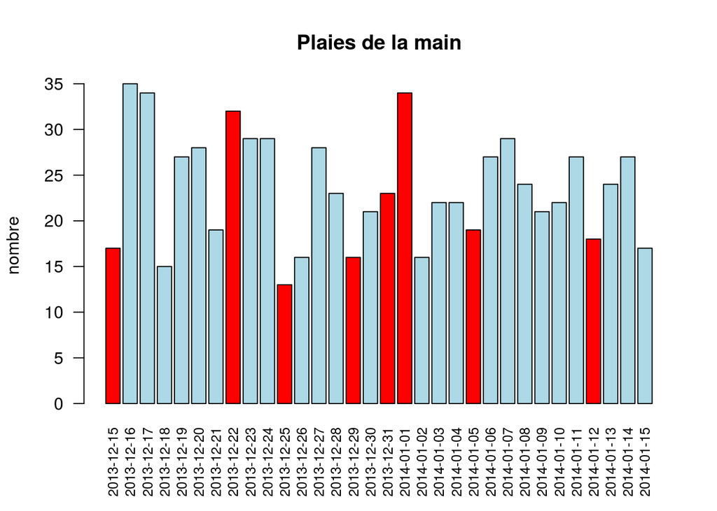

```r
# uniquement les plaies
pet.dp.plaie <- pet[!is.na(pet$DP) & substr(pet$DP, 1, 3) %in% c("S60", "S61"), c("ENTREE","DP")]
t <- tapply(as.Date(pet.dp.plaie$ENTREE), as.Date(pet.dp.plaie$ENTREE), length)
c <- ifelse((wday(names(t)) == 1 | names(t) %in% c("2013-12-25","2013-12-25","2013-12-31","2014-01-01")) == 1, "red", "light blue") # on colorie en rouge les WE et JF
x <- barplot(t, las=2, cex.names=0.8, main = "Plaies de la main", ylab = "nombre", col = c)
```